# Global Health and Economic Development Analysis

Cervical Cancer Deaths vs. GDP per Capita (2000)

By Dr Lameck Luwanda

2025-09-03

## Introduction

This report analyzes the relationship between cervical cancer deaths and economic development across countries in the year 2000. We examine two key indicators:

1. **Cervical Cancer Deaths (2000)**: Number of female deaths from cervical cancer
2. **GDP per Capita (2000)**: Economic prosperity measured by gross domestic product per person

The analysis explores global patterns, regional variations, and the potential relationship between health outcomes and economic development.

## Dataset overview

Summary Statistics: Cervical Cancer Deaths (2000)

| Countries | Mean Deaths | Median Deaths | Min Deaths | Max Deaths |
| --- | --- | --- | --- | --- |
| 204 | 727.1347 | 219.5 | 0.12 | 8570 |

Summary Statistics: GDP per Capita (2000)

| Countries | Mean GDP | Median GDP | Min GDP | Max GDP |
| --- | --- | --- | --- | --- |
| 195 | 2350.219 | 1260 | 10.3 | 9950 |

## World map visualization: Cervical cancer deaths

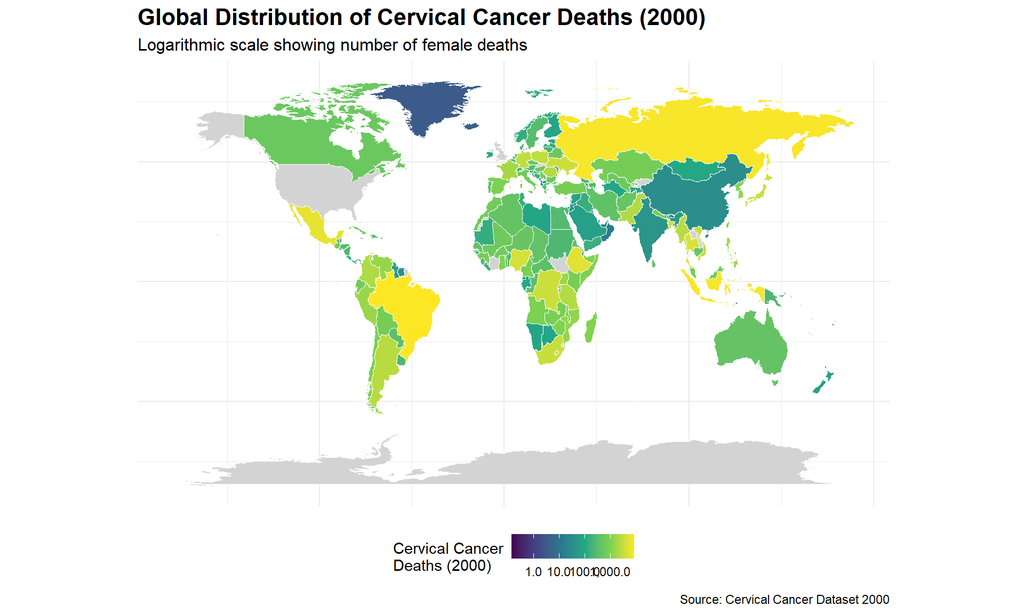

## World map visualization: GDP per Capita

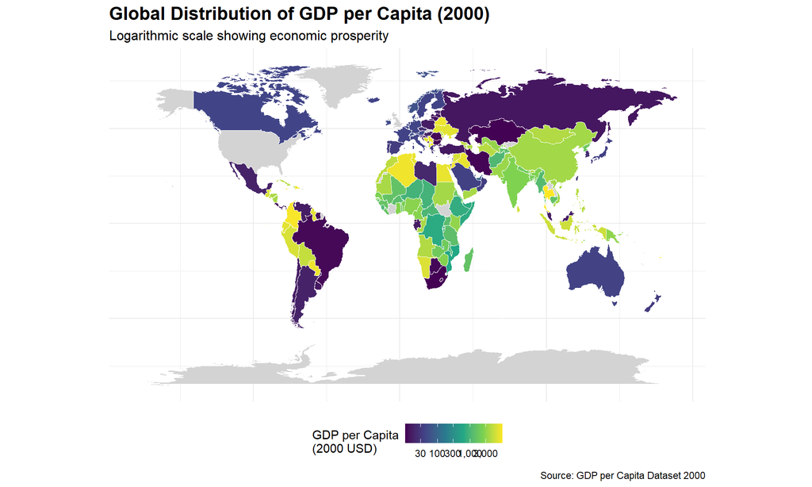

## Data merging and analysis

Summary of Merged Dataset Analysis

| Countries in Analysis | Pearson Correlation (r) | Mean Deaths | Mean GDP |
| --- | --- | --- | --- |
| 194 | -0.0461579 | 763.9531 | 2362.145 |